# Excel tables

Brendan Clarke, NHS Education for Scotland, brendan.clarke2@nhs.scot

01/07/2024

## Welcome

- this session is 🌶: for Excel beginners
- we’ll get going properly at 10.05
- if you can’t access the chat, you might need to join our Teams channel: **tinyurl.com/kindnetwork**
- you can find session materials at **tinyurl.com/kindtrp**

## The KIND network

- a social learning space for staff working with **k**nowledge, **i**nformation, and **d**ata across health, social care, and housing in Scotland
- we offer social support, free training, mentoring, community events, …
- [Teams channel](https://teams.microsoft.com/l/team/19%3AQZ7-PbFVcziG2piHLt1_ifey3I2cwFL0yBuTSS8vVao1%40thread.tacv2/conversations?groupId=106d08f3-9026-40e2-b3c7-87cd87304d58&tenantId=10efe0bd-a030-4bca-809c-b5e6745e499a) / [mailing list](https://forms.office.com/pages/responsepage.aspx?id=veDvEDCgykuAnLXmdF5JmpopIZB9ynRJnrPUHVFccipURjM2NkZJUkhGOFlQRjQxRFhVUTgwT0UwVyQlQCN0PWcu)

## Where does this fit in?

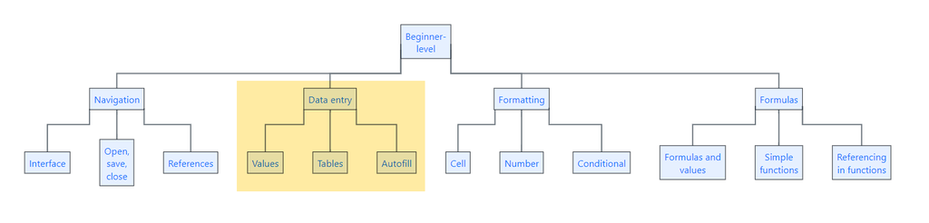

KIND Excel beginner skill tree

- for this session, you’ll need to be familiar with the Excel basics (getting around in Excel, opening/saving/closing files, A1 referencing, and values)
- we’re going to dodge formatting and formulas as much as possible today

## Session outline

- introduction
- add and remove tables
- grow and shrink tables
- autofill and friends
- sort and filter
- names and reference
- pass data to other tools

## Introduction

- this is an easy session to sum up: **use tables in Excel**
- most people don’t use Excel tables
- they’re probably the best Excel skill investment there is
- this is a practical session, so you’ll need some kind of Excel to follow along

## Some data

- tables are potentially useful throughout the life-cycle of an Excel file
- let’s start at the beginning:
  1. open Excel
  2. in a new worksheet, please enter today’s date
     1. DD/MM/YYYY format is best, but we’ll park that for the formatting session

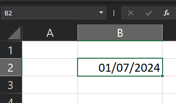

## Add a table

1. make sure you have that date selected
2. In the ribbon menu, go to `Insert` `>` `Table`

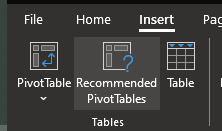

   1. or you can use `Ctrl` + `t`
3. you’ll be asked to create a table - you should be able just to select `OK`

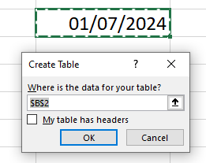

## A first table

- congratulations, you should now have a 1-cell table on your worksheet

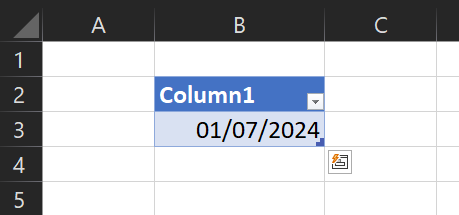

- think about this as a **container** for your data
  - you could call it a **data structure** instead if you wanted to be more fancy

## Removing your table

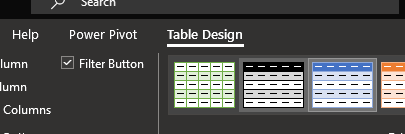

## Grow and shrink tables

Let’s add some new data:

1. Please add three or four more dates, going back into last week, in the rows below your date
2. Please add a word describing your main breakfast item in the next column
3. Please add a third column, scoring that breakfast out of ten

## Grow and shrink tables

4. Now expand your table to include that new data. You can drag the blue handle

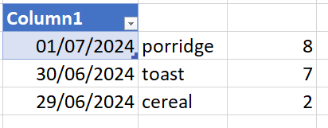

   or use the `Resize Table` tool in the ribbon menu

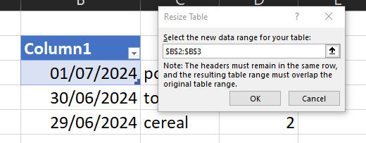

   .
5. You can use the same methods to shrink a table

## Autofill and friends

1. drag down to add two more empty rows
2. select your three dates, and drag the **green** fill handle down into the empty cells

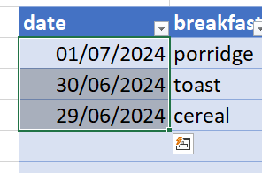

3. this *should* populate the correct values - although you’ll need to check carefully that everything has worked

## Filter and sort

Each of your column headers has a dropdown menu that will allow you to sort and filter your table

- sort allows you to order your table by that column
- filters shows and hides rows of the table
- you’ll have different filtering options for the different types of columns in your table

## Names and reference

- you can name each column. These work best as single descriptive words - `date` rather than `breakfast date`
  - you might find it helpful to write longer names in snake case (`breakfast_date`) or camel case (`breakfastDate`)
  - please now name your columns
- you can also name the table as a whole. Again, that’s done from the left-hand side of the `Table` menu
  - please give your table an appropriate name

## Passing data demo

- Your table can now be saved, developed further, or passed to other data tools
- Tables have major advantages on this front:
  - they’re portable, so you can move a table around
  - you can use **structured referencing** - like `=data[score]` - to select an entire column by name, which helps make Excel more robust
    - see the intermediate Excel session on referencing
  - you can send the data easily and safely to PivotTables, PowerQuery, PowerPivot, and other fancier data tools

## CONCLUSION: USE TABLES

## Forthcoming Excel sessions

| Session | Date | Area | Level |
| --- | --- | --- | --- |
| Excel tables | 10:00-10:30 Mon 1st July 2024 | Excel | 🌶 :**beginner-level** |
| Formulas in Excel | 15:00-16:00 Wed 3rd July 2024 | Excel | 🌶 :**beginner-level** |
| Lambda formulas in Excel | 13:00-13:30 Mon 15th July 2024 | Excel | 🌶🌶 : **intermediate-level** |
| Lookups in Excel | 13:00-14:30 Thu 1st August 2024 | Excel | 🌶🌶 : **intermediate-level** |
| Relative, absolute, mixed, structured, and R1C1 references in Excel | 15:00-16:00 Thu 8th August 2024 | Excel | 🌶🌶 : **intermediate-level** |

## Feedback

Feedback link

Please give us one minute of your time. We add feedback comments to our training pages, because we think this is the most useful resource for people looking for specific training that suits their needs